# OM Sensitivity report

ABT-MSE

Tom Carruthers

June 12, 2019

# 1 Introduction / notes

[output not shown]

# 2 Comparison of global likelihoods

Table 1. These are weighted negative log-likelihoods. Color coding is by column. Rows with all black values depict models that did not converge.

| OM | Code | Cat | CR | Surv | Comp | SOOm | SOOg | Tag | Rec | Mov | Sel | SRA | R0diff | MI | TOT_nP | TOT |
| --- | --- | --- | --- | --- | --- | --- | --- | --- | --- | --- | --- | --- | --- | --- | --- | --- |
| 1 | 1AI | -552 | 238 | 216 | 429 | 339 | 142 | 201 | 26 | 49 | 35 | 0 | 46 | 79 | 1013 | 1248 |
| 7 | 1AII | -553 | 240 | 229 | 434 | 347 | 144 | 726 | 31 | 50 | 36 | 0 | 44 | 83 | 1567 | 1811 |
| 1 | 1AI_DW_SOOm | -551 | 215 | 199 | 426 | 675 | 133 | 203 | 24 | 50 | 35 | 0 | 51 | 84 | 1300 | 1544 |

Cat = catch data by fleet, quarter and area. CR = the fishery dependent catch rate (CPUE) indices, Surv = fishery-independent survey indices, Comp = length composition data, SOOm = stock of origin microchemistry data, SOOg = stock of origin genetics, Tag = Electronic tagging data, Rec = prior on recruitment deviations, Mov = prior on movement parameters, Sel = prior on size selectivity parameters, SRA = penalty incurred when catches exceed F=1 catches in the stock reduction analysis phase (1864-1964), MI = a prior on similarity to the ‘Master Index’ that predicts F by year, area, season and fleet, R0diff = a prior on the difference in R0 estimated in two-phase recruitment models (recruitment level 1 and 3), TOT_nP = total global objective function without priors, TOT = total global objective function.

Table 2. These are weighted negative log-likelihoods expressed as differences from the base-case weighting. Color coding is by column. Rows with all black values depict models that did not converge.

| OM | Code | Cat | CR | Surv | Comp | SOOm | SOOg | Tag | Rec | Mov | Sel | SRA | R0diff | MI | TOT_nP | TOT |
| --- | --- | --- | --- | --- | --- | --- | --- | --- | --- | --- | --- | --- | --- | --- | --- | --- |
| 1 | 1AI | 0 | 0 | 0 | 0 | 0 | 0 | 0 | 0 | 0 | 0 | 0 | 0 | 0 | 0 | 0 |
| 7 | 1AII | -1 | 2 | 13 | 5 | 8 | 2 | 525 | 5 | 1 | 1 | 0 | -2 | 4 | 554 | 563 |
| 1 | 1AI_DW_SOOm | 1 | -23 | -17 | -3 | 336 | -9 | 2 | -2 | 1 | 0 | 0 | 5 | 5 | 287 | 296 |

# 3 Comparison with 2017 Stock Assessments

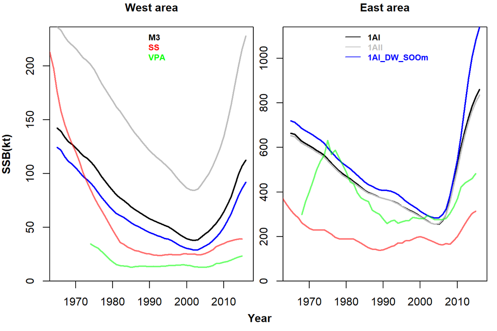

Figure 1. Regional spawning stock comparisons (by area, divisible by 45deg W) with 2017 stock assessment. Note that annual estimates from the operating model are calculated from average of the seasonal predictions.

# 4 Spawning Stock Biomass

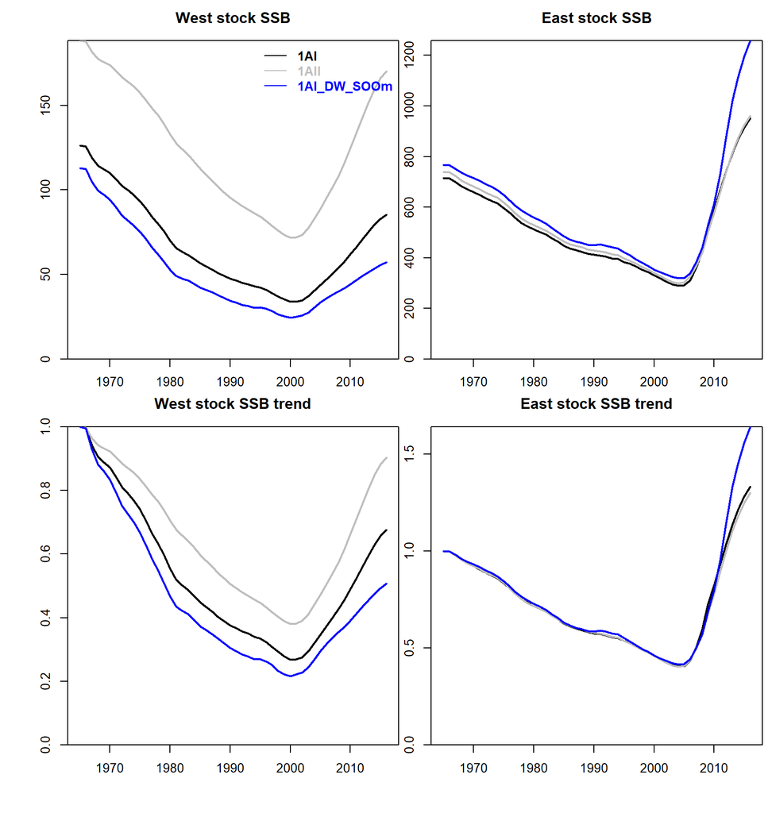

# 5 Stock mixing

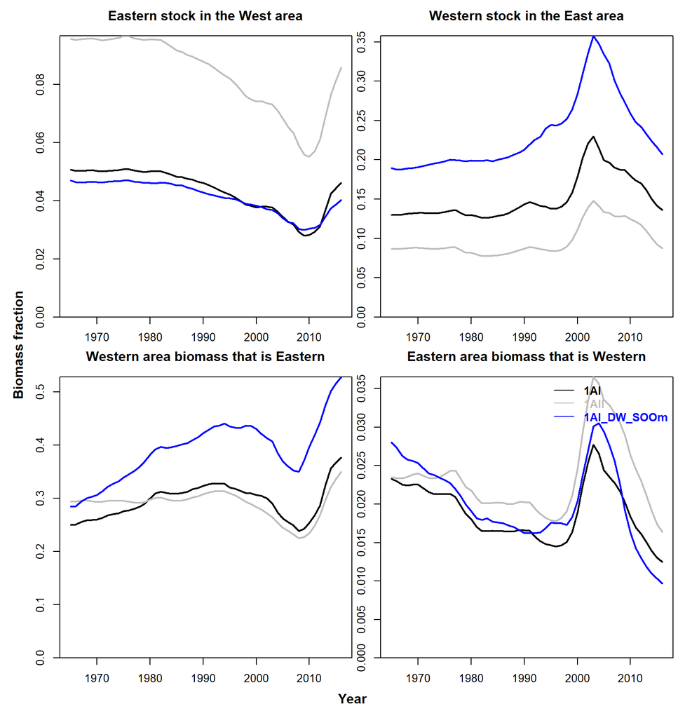

Figure 3. Biomass fractions by stock (top row) and area (bottom row).